# EDA and Classification Models

# 1.EDA

## 1.1 Loading Data

```r
df <- read.csv("dssplice.csv",stringsAsFactors=T)

dim(df)
```

```
## [1] 3190   62
```

# Dimension of data is found to be 3190*62 which means there are 3190 rows(number of observations) and 62 columns(number of variables) in this dataset. # The number of columns include 61 features and 1 class variable.

## 1.2 Data Description

```r
names(df)
```

```
##  [1] "Instance_name" "attribute_1"   "attribute_2"   "attribute_3"
##  [5] "attribute_4"   "attribute_5"   "attribute_6"   "attribute_7"
##  [9] "attribute_8"   "attribute_9"   "attribute_10"  "attribute_11"
## [13] "attribute_12"  "attribute_13"  "attribute_14"  "attribute_15"
## [17] "attribute_16"  "attribute_17"  "attribute_18"  "attribute_19"
## [21] "attribute_20"  "attribute_21"  "attribute_22"  "attribute_23"
## [25] "attribute_24"  "attribute_25"  "attribute_26"  "attribute_27"
## [29] "attribute_28"  "attribute_29"  "attribute_30"  "attribute_31"
## [33] "attribute_32"  "attribute_33"  "attribute_34"  "attribute_35"
## [37] "attribute_36"  "attribute_37"  "attribute_38"  "attribute_39"
## [41] "attribute_40"  "attribute_41"  "attribute_42"  "attribute_43"
## [45] "attribute_44"  "attribute_45"  "attribute_46"  "attribute_47"
## [49] "attribute_48"  "attribute_49"  "attribute_50"  "attribute_51"
## [53] "attribute_52"  "attribute_53"  "attribute_54"  "attribute_55"
## [57] "attribute_56"  "attribute_57"  "attribute_58"  "attribute_59"
## [61] "attribute_60"  "Class"
```

```r
head(df)
```

```
##        Instance_name attribute_1 attribute_2 attribute_3 attribute_4
## 1   ATRINS-DONOR-521           C           C           A           G
## 2   ATRINS-DONOR-905           A           G           A           C
## 3   BABAPOE-DONOR-30           G           A           G           G
## 4  BABAPOE-DONOR-867           G           G           G           C
## 5 BABAPOE-DONOR-2817           G           C           T           C
## 6 CHPIGECA-DONOR-378           C           A           G           A
##   attribute_5 attribute_6 attribute_7 attribute_8 attribute_9 attribute_10
## 1           C           T           G           C           A            T
## 2           C           C           G           C           C            G
## 3           T           G           A           A           G            G
## 4           T           G           C           G           T            T
## 5           A           G           C           C           C            C
## 6           C           T           G           G           G            T
##   attribute_11 attribute_12 attribute_13 attribute_14 attribute_15 attribute_16
```

[output cut: 62 more lines]

# We can see from above output, all the features(independent columns) have character values so we have all categorical features in our data. #“Instance_name” field corresponds to individual’s ID for which all rest of 60 characteristic and class field is populated.

## 1.3 Analysis

```r
summary(df)
```

```
##                  Instance_name  attribute_1 attribute_2 attribute_3 attribute_4
##  HUMALBGC-ACCEPTOR-18496:   2   A:743       A:779       A:712       A:753
##  HUMALBGC-DONOR-17044   :   2   C:835       C:858       C:876       C:884
##  HUMMYC3L-ACCEPTOR-4242 :   2   D:  1       D:  1       G:841       G:802
##  HUMMYLCA-ACCEPTOR-1831 :   2   G:876       G:794       T:761       T:751
##  HUMMYLCA-ACCEPTOR-2214 :   2   T:735       T:758
##  HUMMYLCA-ACCEPTOR-2481 :   2
##  (Other)                :3178
##  attribute_5 attribute_6 attribute_7 attribute_8 attribute_9 attribute_10
##  A:801       A:704       A:783       A:790       A:749       A:767
##  C:865       C:898       C:858       C:878       C:909       C:808
##  G:719       G:828       G:780       G:731       G:749       G:766
##  T:805       T:760       T:769       T:791       T:783       T:849
##
##
##
##  attribute_11 attribute_12 attribute_13 attribute_14 attribute_15 attribute_16
##  A:717        A:668        A:738        A:797        A:665        A:700
##  C:823        C:930        C:878        C:898        C:959        C:949
##  G:778        G:807        G:752        G:712        G:768        G:684
##  T:872        T:785        T:822        N:  1        T:798        T:857
##                                         T:782
##
##
##  attribute_17 attribute_18 attribute_19 attribute_20 attribute_21 attribute_22
##  A:670        A:649        A:657        A:693        A:640        A:702
##  C:908        C:889        C:921        C:889        C:938        C:923
##  G:701        G:746        G:712        G:671        G:697        G:716
##  T:911        T:906        N:  1        N:  2        N:  2        N:  1
##                            T:899        T:935        T:913        T:848
##
##
##  attribute_23 attribute_24 attribute_25 attribute_26 attribute_27 attribute_28
##  A:662        A:638        A:652        A:667        A:769        A: 696
##  C:968        C:952        C:946        C:892        C:883        C:1309
##  G:702        G:706        G:704        G:660        G:855        G: 576
##  N:  1        N:  1        N:  1        N:  1        N:  1        N:   1
##  T:857        T:893        T:887        T:970        T:682        T: 608
##
##
```

[output cut: 33 more lines]

```
##  A:733        A:695        A:802        A:756        A:743        A:720
##  C:832        C:818        C:835        C:831        C:790        C:870
##  G:874        G:934        G:859        G:838        G:908        G:866
##  N:  1        N:  1        N:  1        N:  2        N:  1        N:  1
##  T:750        T:742        T:693        T:763        T:748        T:733
##
##
##  attribute_59 attribute_60 Class
##  A:785        A:721        EI: 767
##  C:860        C:785        IE: 768
##  G:789        G:953        N :1655
##  N:  1        N:  1
##  T:755        T:730
##
##
```

From above summary report, we can see that all 60 features have “A”,“C”,“D”,“G”,“T”,“N”,“R”,“S” values distributed almost equally except for “D”,N”,“R” and “S” values which have very few counts in all features. “Class” variable has three categories i.e., “EI”, “IE” and “N” out of which “N” has highest occurring. Since number of classes is larger than 2, so we are dealing with Multi-class Classification.

```r
table(df$Class)
```

```
##
##   EI   IE    N
##  767  768 1655
```

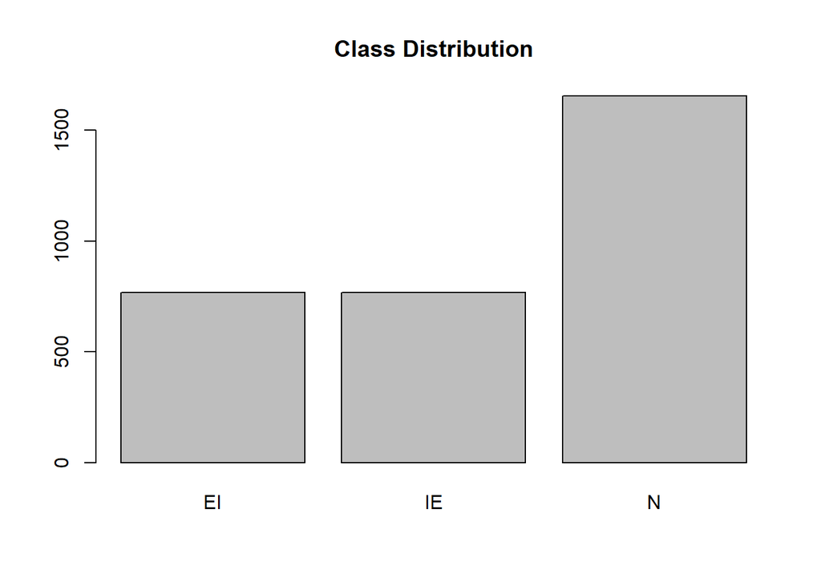

```r
barplot(table(df$Class),
        main = "Class Distribution")
```

By looking at frequency distribution of classes, we can say there is a class imbalance issue since “N” has 2:1 count ratio with both “EI” and “IE” classes. We will handle imbalance issue later in same report.

### 1.4 Checking Missing values

There are no missing values in data.

```r
sum(is.na(df))
```

```
## [1] 0
```

### 1.5 Visualization

Bar plots of few of the features is shown in below image. And approximately all values are equally distributed as summarized earlier.

```r
library(dplyr)
```

```r
library(ggplot2)
library(purrr)
library(tidyr)
df1 <- df[,c(-1,-62)]
df1 %>%
  gather() %>%
  ggplot(aes(value)) +
    facet_wrap(~ key, scales = "free",nrow=20) +
    geom_bar()
```

[figure not shown]

# 2. Classification Models

### 2.1 Checking Important features

# We will find out best features using variable importance and compare performance of model using best features and model using all features

```r
library(rpart)
require(rpart)

#drop irrelevant column
df2 <- df[,-1]
tree<-rpart(Class~.,data=df2)
tree$variable.importance
```

```
## attribute_30 attribute_29 attribute_31 attribute_32 attribute_35 attribute_33
##   521.286072   485.782988   468.041190   367.334307   210.868284   208.552794
## attribute_28 attribute_34 attribute_36 attribute_23 attribute_25 attribute_20
##   198.241961   137.170224    58.324293    43.514720    38.385496    19.415111
## attribute_22 attribute_26 attribute_21 attribute_24 attribute_17 attribute_16
##    16.082634    14.269239    12.999895    10.087156     6.560914     1.174898
```

# Above result shows significant features to determine Class of an observation. “attribute_30” is the most significant feature among all 60 features.

## 2.2 Train-test split

# Splitting the data into train and test samples to perform further classification modeling on this data with Class variable as target and rest of #variables as predictors.

```r
set.seed(12)
train_index = sample(1:nrow(df2), 0.70*nrow(df2))
train = df2[train_index, ]
test = df2[-train_index, ]
```

## 2.3 Handling Class Imbalance in training data

# We can see that 1123 observations is class “N” which almost twice of 560 observation in “EI” and 550 observation in “IE” which implies class #imbalance issue in training data.

#Based on proportion table, 50% is in “N” class, 25% and 24% in “EI” and “IE” classes respectively. #There is an imbalance in all the classes in both TRAIN and TEST set, and imbalanced classes may create bias in the predictive model and impact the #accuracy of the model, so the next step is to balance all the classes. Here, we are only to balance the classes in TRAIN data set only in order to #prevent overfitting on our performances.

```r
table(train$Class)
```

```
##
##   EI   IE    N
##  560  550 1123
```

```r
prop.table(table(train$Class))
```

```
##
##        EI        IE         N
## 0.2507837 0.2463054 0.5029109
```

### 2.3.1 Assigning weights

#We will assign weights to each observation basis Class variable proportion to equalise the proportion in training set in all further classification #techniques. Computed weight vector in formats as required in respective functions in R.

```r
# WE are using ifelse  referencing  train$class  and  going into the frequency table find out how many  N  in our set.
# and assign each group to have 1/3

wt <- ifelse(train$Class == "EI",
                        (1/table(train$Class)[1]) * (1/3),
            ifelse(train$Class == "IE",
                        (1/table(train$Class)[2]) * (1/3),
                        (1/table(train$Class)[3]) * (1/3)))

wt_svm = 100 / table(train$Class)
```

## 2.4 Logistic Regression

#The logistic classification model (or logit model) is a binary classification model in which the conditional probability of one of the two possible #realizations of the output variable is assumed to be equal to a linear combination of the input variables, transformed by the logistic function.

Comparing model with all features and 18 best features.

```r
#model with all 60 features  // implicitly taking care of the hot encoding for logistic, SVM and Decision Tree.

logistic_fit_60 = nnet::multinom(Class~.,train, weights = wt)
summary(logistic_fit_60)
```

```
## Call:
## nnet::multinom(formula = Class ~ ., data = train, weights = wt)
##
## Coefficients:
##    (Intercept) attribute_1C attribute_1D attribute_1G attribute_1T attribute_2C
## IE   -19.93493     3.295373            0   -2.6473507    0.2512032    -2.607964
## N     32.90971     4.174773            0   -0.9675938    3.5740455     3.096081
##    attribute_2D attribute_2G attribute_2T attribute_3C attribute_3G
## IE            0     3.262441     3.769225   -4.2581655    -5.637658
## N             0     3.794935     9.356837   -0.8889345     7.416810
##    attribute_3T attribute_4C attribute_4G attribute_4T attribute_5C
## IE     3.979275    -5.610859     2.569453   -0.1620257   -0.7272919
## N     -2.585144    -7.295393    -2.622300    6.1642653   -2.7827440
##    attribute_5G attribute_5T attribute_6C attribute_6G attribute_6T
## IE    0.2339979     3.848431   -0.6124692    -1.188841     7.620019
## N     4.2686986     7.351945   -3.0933646    -3.241788     5.534933
##    attribute_7C attribute_7G attribute_7T attribute_8C attribute_8G
## IE     6.029204    -1.304125     4.794730     -7.10616    2.8473729
## N      7.237800     3.441523     2.980719    -10.26568   -0.7200885
##    attribute_8T attribute_9C attribute_9G attribute_9T attribute_10C
## IE     0.674062     3.535923    -5.170168     4.895462      3.891254
## N      8.900956     3.435218     3.322514    -4.267998     11.957315
##    attribute_10G attribute_10T attribute_11C attribute_11G attribute_11T
## IE     -4.209870      4.949376    -0.3860198    -0.1359204      6.307114
## N       2.313605      3.230087    -5.5732729    -1.6303106      4.819912
##    attribute_12C attribute_12G attribute_12T attribute_13C attribute_13G
## IE     -2.564479    -12.677162      3.505734    2.49845184      1.363997
## N      -5.748700     -2.203453      6.211097    0.06401471      2.255237
##    attribute_13T attribute_14C attribute_14G attribute_14N attribute_14T
## IE      7.987558      1.933131     0.3337001             0      4.733472
## N       5.643110      3.182390     6.5997433             0      1.591526
##    attribute_15C attribute_15G attribute_15T attribute_16C attribute_16G
## IE      3.675546     -6.482650      4.111847      6.130661      6.225376
## N      -1.061171      3.810835     -2.825544      7.602801     14.597217
##    attribute_16T attribute_17C attribute_17G attribute_17T attribute_18C
## IE      2.323823      6.564640     -9.554434      4.801991     1.9415241
## N       6.274085      6.439631     -3.490257      7.032159     0.4026818
##    attribute_18G attribute_18T attribute_19C attribute_19G attribute_19N
## IE     -1.015159      5.128723     9.5520663      4.322844             0
## N       3.082726      3.873794     0.0978592      9.911279             0
```

[output cut: 230 more lines]

```
##    attribute_56T attribute_57C attribute_57G attribute_57N attribute_57T
## IE      6300.354      5612.743      6345.901  9.137452e-09      5454.317
## N       6190.472      5148.770      4185.422  1.760063e+03      5223.836
##    attribute_58C attribute_58G attribute_58N attribute_58T attribute_59C
## IE      5224.793      5194.283  9.007880e-09      4831.847      5346.509
## N       4392.960      5315.173  1.760063e+03      5309.478      4663.886
##    attribute_59G attribute_59N attribute_59T attribute_60C attribute_60G
## IE      6089.368  8.928677e-09      5500.688      7074.410      5583.758
## N       4166.585  1.760063e+03      5275.849      5775.269      6020.052
##    attribute_60N attribute_60T
## IE  8.915569e-09      5881.189
## N   1.760063e+03      4549.782
##
## Residual Deviance: 0.0268107
## AIC: 748.0268
```

```r
# Make predictions

pred <- predict(logistic_fit_60,test)

# Model accuracy
#  to compare the value 1,0  it will accumulate each observation

mean(pred == test$Class)
```

```
## [1] 0.9122257
```

```r
AIC(logistic_fit_60)
```

```
## [1] 748.0268
```

```r
#Model with best 18 features selected using variable importance

logistic_fit_18 = nnet::multinom(Class~attribute_30 +attribute_29+attribute_31+attribute_32+ attribute_35+attribute_33 + attribute_28 + attribute_34+ attribute_36 + attribute_23 +attribute_25+attribute_20+attribute_22 + attribute_26 + attribute_21 + attribute_24 + attribute_17 + attribute_16, train, weights = wt)
# Make predictions

pred_class_log <- predict(logistic_fit_18,test)

# Model accuracy

print("Accuracy of Logistic model is:")
```

```
## [1] "Accuracy of Logistic model is:"
```

```r
acc_logistic <- mean(pred_class_log == test$Class)
acc_logistic
```

```
## [1] 0.9519331
```

```r
AIC(logistic_fit_18)
```

```
## [1] 232.1788
```

#We can see that model using best 18 features(accuracy:95%, AIC= 232) is much better performing than model with all features(accuracy:91%, AIC:748) in #terms of AIC and accuracy both. #So we will use these 18 variables only going forward in models.

### 2.4.1 Model Performance Evaluation

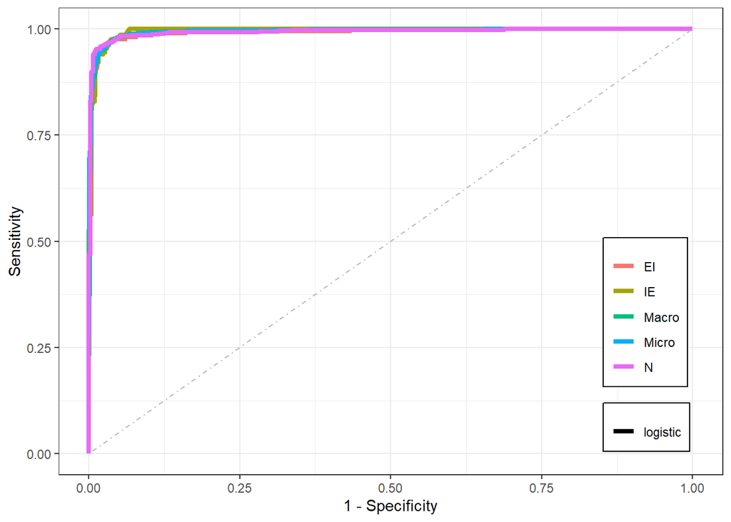

```r
# ROC plot
library(pROC)
pred_logistic <- predict(logistic_fit_18, test, type = 'prob')
pred_logistic <- data.frame(pred_logistic)
colnames(pred_logistic) <- paste(colnames(pred_logistic), "_pred_logistic")

# Merge true labels and predicted values
true_label <- dummies::dummy(test$Class, sep = ".")
true_label <- data.frame(true_label)
colnames(true_label) <- gsub(".*?\\.", "", colnames(true_label))
colnames(true_label) <- paste(colnames(true_label), "_true")

final_df <- cbind(true_label, pred_logistic)

# multiROC
require(multiROC)
roc_res <- multi_roc(final_df, force_diag=T)

# Plot

plot_roc_df <- plot_roc_data(roc_res)

require(ggplot2)
ggplot(plot_roc_df, aes(x = 1-Specificity, y=Sensitivity)) +
  geom_path(aes(color = Group, linetype=Method), size=1.5) +
  geom_segment(aes(x = 0, y = 0, xend = 1, yend = 1),
                        colour='grey', linetype = 'dotdash') +
  theme_bw() +
  theme(plot.title = element_text(hjust = 0.5),
                 legend.justification=c(1, 0), legend.position=c(.95, .05),
                 legend.title=element_blank(),
                 legend.background = element_rect(fill=NULL, size=0.5,
                                                           linetype="solid", colour ="black"))
```

```r
# AUC

prob <- predict(logistic_fit_18, test, type = 'prob')
auc_logistic <- multiclass.roc(test$Class,prob) #AUC score
auc_logistic
```

```
##
## Call:
## multiclass.roc.default(response = test$Class, predictor = prob)
##
## Data: multivariate predictor prob with 3 levels of test$Class: EI, IE, N.
## Multi-class area under the curve: 0.9938
```

```r
# confusion matrix
cm <- table(test$Class, pred_class_log )
cm
```

```
##     pred_class_log
##       EI  IE   N
##   EI 196   6   5
##   IE   7 208   3
##   N    9  16 507
```

```r
# Specificity

Specificty_class_EI <- (cm[2, 2] + cm[3, 3])/(cm[2, 1] + cm[3, 1] + cm[2, 2] + cm[3, 3])

Specificty_class_IE <- (cm[1, 1] + cm[3, 3])/(cm[1, 2] + cm[3, 2] + cm[1, 1] + cm[3, 3])

Specificty_class_N <- (cm[2, 2] + cm[1, 1])/(cm[1, 3] + cm[2, 3] + cm[2, 2] + cm[1, 1])

spec_logistic <- matrix(c(Specificty_class_EI,Specificty_class_IE,Specificty_class_N),nrow=1,dimnames=list("",c("EI","IE","N")))
spec_logistic
```

```
##         EI        IE         N
##  0.9781122 0.9696552 0.9805825
```

```r
# Precision
prec_logistic <- (diag(cm) / colSums(cm))
prec_logistic
```

```
##        EI        IE         N
## 0.9245283 0.9043478 0.9844660
```

```r
# Recall(sensitivity) for each class
recall_logistic <- (diag(cm) / rowSums(cm))
recall_logistic
```

```
##        EI        IE         N
## 0.9468599 0.9541284 0.9530075
```

## 2.5 SVM Classification

#Support vector machines (SVMs) are powerful yet flexible supervised machine learning algorithms which are used both for classification and regression. #But generally, they are used in classification problems.An SVM model is basically a representation of different classes in a hyperplane in #multidimensional space. The hyperplane will be generated in an iterative manner by SVM so that the error can be minimized. The goal of SVM is to #divide the datasets into classes to find a maximum marginal hyperplane (MMH).

```r
# loading library required

library(e1071)


# fitting model on training data

svmfit = svm(Class ~ attribute_30 +attribute_29+attribute_31+attribute_32+ attribute_35+attribute_33 + attribute_28 + attribute_34+ attribute_36 + attribute_23 +attribute_25+attribute_20+attribute_22 + attribute_26 + attribute_21 + attribute_24 + attribute_17 + attribute_16,
             data = train, method="C-classification", kernel = "radial", cost = 10, scale = FALSE, class.weights =wt_svm, probability=TRUE)


# Make predictions
pred_class_svm = predict(svmfit, test)
```

### 2.5.1 Model Performance Evaluation

```r
# Model accuracy
acc_svm <- mean(pred_class_svm == test$Class)
acc_svm
```

```
## [1] 0.9435737
```

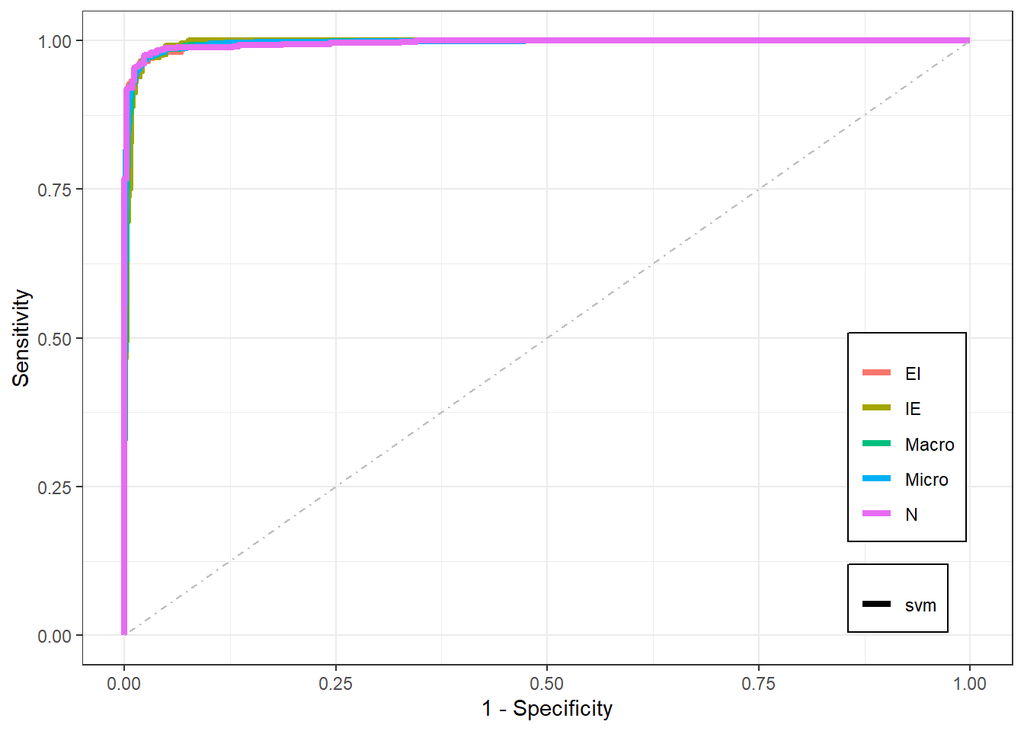

```r
# ROC plot

pred_svm <- predict(svmfit, test, probability = TRUE)
pred_svm <- data.frame(attr(pred_svm, "probabilities"))
colnames(pred_svm) <- paste(colnames(pred_svm), "_pred_svm")

# Merge true labels and predicted values
true_label <- dummies::dummy(test$Class, sep = ".")
true_label <- data.frame(true_label)
colnames(true_label) <- gsub(".*?\\.", "", colnames(true_label))
colnames(true_label) <- paste(colnames(true_label), "_true")

final_df <- cbind(true_label, pred_svm)

# multiROC
require(multiROC)
roc_res <- multi_roc(final_df, force_diag=T)

# Plot
plot_roc_df <- plot_roc_data(roc_res)

require(ggplot2)
ggplot(plot_roc_df, aes(x = 1-Specificity, y=Sensitivity)) +
  geom_path(aes(color = Group, linetype=Method), size=1.5) +
  geom_segment(aes(x = 0, y = 0, xend = 1, yend = 1),
                        colour='grey', linetype = 'dotdash') +
  theme_bw() +
  theme(plot.title = element_text(hjust = 0.5),
                 legend.justification=c(1, 0), legend.position=c(.95, .05),
                 legend.title=element_blank(),
                 legend.background = element_rect(fill=NULL, size=0.5,
                                                           linetype="solid", colour ="black"))
```

```r
# AUC

prob <- predict(svmfit, test, probability = TRUE)
auc_svm <- multiclass.roc(test$Class,attr(prob, "probabilities")) #AUC score
auc_svm
```

```
##
## Call:
## multiclass.roc.default(response = test$Class, predictor = attr(prob,     "probabilities"))
##
## Data: multivariate predictor attr(prob, "probabilities") with 3 levels of test$Class: EI, IE, N.
## Multi-class area under the curve: 0.9956
```

```r
# confusion matrix
cm <- table(test$Class, pred_class_svm )
cm
```

```
##     pred_class_svm
##       EI  IE   N
##   EI 202   4   1
##   IE   7 209   2
##   N   21  19 492
```

```r
# Specificity

Specificty_class_EI <- (cm[2, 2] + cm[3, 3])/(cm[2, 1] + cm[3, 1] + cm[2, 2] + cm[3, 3])

Specificty_class_IE <- (cm[1, 1] + cm[3, 3])/(cm[1, 2] + cm[3, 2] + cm[1, 1] + cm[3, 3])

Specificty_class_N <- (cm[2, 2] + cm[1, 1])/(cm[1, 3] + cm[2, 3] + cm[2, 2] + cm[1, 1])

spec_svm <- matrix(c(Specificty_class_EI,Specificty_class_IE,Specificty_class_N),nrow=1,dimnames=list("",c("EI","IE","N")))


# Precision
prec_svm <- (diag(cm) / colSums(cm))
prec_svm
```

```
##        EI        IE         N
## 0.8782609 0.9008621 0.9939394
```

```r
# Recall(sensitivity) for each class
recall_svm <- (diag(cm) / rowSums(cm))
recall_svm
```

```
##        EI        IE         N
## 0.9758454 0.9587156 0.9248120
```

## 2.6 Decision Tree

#Decision tree algorithm falls under the category of supervised learning. They can be used to solve both regression and classification #problems.Decision tree uses the tree representation to solve the problem in which each leaf node corresponds to a class label and attributes are #represented on the internal node of the tree.

```r
# fitting decision on training data set


tree<-rpart(Class~attribute_30 +attribute_29+attribute_31+attribute_32+ attribute_35+attribute_33 + attribute_28 + attribute_34+ attribute_36 + attribute_23 +attribute_25+attribute_20+attribute_22 + attribute_26 + attribute_21 + attribute_24 + attribute_17 + attribute_16, data=train,weights = wt)


# Make predictions

pred_class_tree = predict(tree, newdata=test,type="class")
```

### 2.6.1 Model Performance Evaluation

```r
# Model accuracy
acc_tree <- mean(pred_class_tree == test$Class)
acc_tree
```

```
## [1] 0.9268548
```

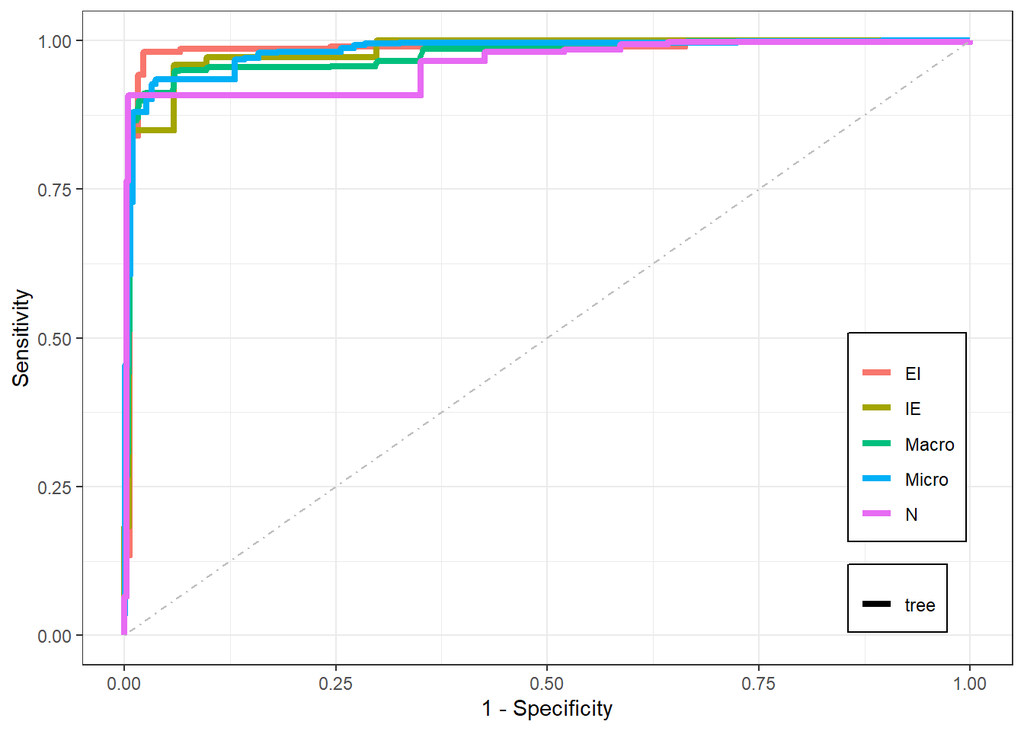

```r
# ROC plot

pred_tree <- predict(tree, test, type='prob')
pred_tree <- data.frame(pred_tree)
colnames(pred_tree) <- paste(colnames(pred_tree), "_pred_tree")

# Merge true labels and predicted values
true_label <- dummies::dummy(test$Class, sep = ".")
true_label <- data.frame(true_label)
colnames(true_label) <- gsub(".*?\\.", "", colnames(true_label))
colnames(true_label) <- paste(colnames(true_label), "_true")

final_df <- cbind(true_label, pred_tree)

# multiROC

require(multiROC)
roc_res <- multi_roc(final_df, force_diag=T)

# Plot
plot_roc_df <- plot_roc_data(roc_res)

require(ggplot2)
ggplot(plot_roc_df, aes(x = 1-Specificity, y=Sensitivity)) +
  geom_path(aes(color = Group, linetype=Method), size=1.5) +
  geom_segment(aes(x = 0, y = 0, xend = 1, yend = 1),
                        colour='grey', linetype = 'dotdash') +
  theme_bw() +
  theme(plot.title = element_text(hjust = 0.5),
                 legend.justification=c(1, 0), legend.position=c(.95, .05),
                 legend.title=element_blank(),
                 legend.background = element_rect(fill=NULL, size=0.5,
                                                           linetype="solid", colour ="black"))
```

```r
# AUC

prob <- predict(tree, test, type='prob')
auc_tree <- multiclass.roc(test$Class,prob) #AUC score
auc_tree
```

```
##
## Call:
## multiclass.roc.default(response = test$Class, predictor = prob)
##
## Data: multivariate predictor prob with 3 levels of test$Class: EI, IE, N.
## Multi-class area under the curve: 0.974
```

```r
# confusion matrix

cm <- table(test$Class, pred_class_tree )
cm
```

```
##     pred_class_tree
##       EI  IE   N
##   EI 195  10   2
##   IE   9 209   0
##   N    8  41 483
```

```r
# Specificity

Specificty_class_EI <- (cm[2, 2] + cm[3, 3])/(cm[2, 1] + cm[3, 1] + cm[2, 2] + cm[3, 3])

Specificty_class_IE <- (cm[1, 1] + cm[3, 3])/(cm[1, 2] + cm[3, 2] + cm[1, 1] + cm[3, 3])

Specificty_class_N <- (cm[2, 2] + cm[1, 1])/(cm[1, 3] + cm[2, 3] + cm[2, 2] + cm[1, 1])

spec_tree <- matrix(c(Specificty_class_EI,Specificty_class_IE,Specificty_class_N),nrow=1,dimnames=list("",c("EI","IE","N")))
spec_tree
```

```
##         EI        IE         N
##  0.9760226 0.9300412 0.9950739
```

```r
# Precision

prec_tree <- (diag(cm) / colSums(cm))
prec_tree
```

```
##        EI        IE         N
## 0.9198113 0.8038462 0.9958763
```

```r
# Recall(sensitivity) for each class
recall_tree <- (diag(cm) / rowSums(cm))
recall_tree
```

```
##        EI        IE         N
## 0.9420290 0.9587156 0.9078947
```

## 2.7 K Nearest Neighbor

#K-nearest neighbors (kNN) is a non-parametric method for classification, meaning that there #are no model parameters to estimate. The knn() function from class package is used, which takes the training set, its labels, and testing set as #inputs, and returns the class predictions for the testing set.

```r
library(class)
library(caret)
# preparing data     Hot Encoding    as  KNN   doesnot accept categorical target that we did hot encoding

x_train <- train[,c('attribute_30', 'attribute_29', 'attribute_31', 'attribute_32', 'attribute_35', 'attribute_33', 'attribute_28', 'attribute_34', 'attribute_36', 'attribute_23', 'attribute_25', 'attribute_20', 'attribute_22', 'attribute_26', 'attribute_21', 'attribute_24', 'attribute_17', 'attribute_16')]
y_train <- train$Class

x_test <- test[,c('attribute_30', 'attribute_29', 'attribute_31', 'attribute_32', 'attribute_35', 'attribute_33', 'attribute_28', 'attribute_34', 'attribute_36', 'attribute_23', 'attribute_25', 'attribute_20', 'attribute_22', 'attribute_26', 'attribute_21', 'attribute_24', 'attribute_17', 'attribute_16')]
y_test <- test$Class


library(fastDummies)

# Create dummy variable since KNN only handles numerical variables
x_dummy_train <- dummy_cols(x_train, select_columns = colnames(x_train), remove_selected_columns = T)
x_dummy_test <- dummy_cols(x_test, select_columns = colnames(x_test), remove_selected_columns = T)

#KNN model
knn <- train(x_dummy_train,y_train, method="knn")

# Make predictions
pred_class_knn = predict(knn, newdata=x_dummy_test,type="raw")
```

### 2.7.1 Model Performance Evaluation

```r
# Model accuracy
acc_knn <- mean(pred_class_knn == y_test)
acc_knn
```

```
## [1] 0.846395
```

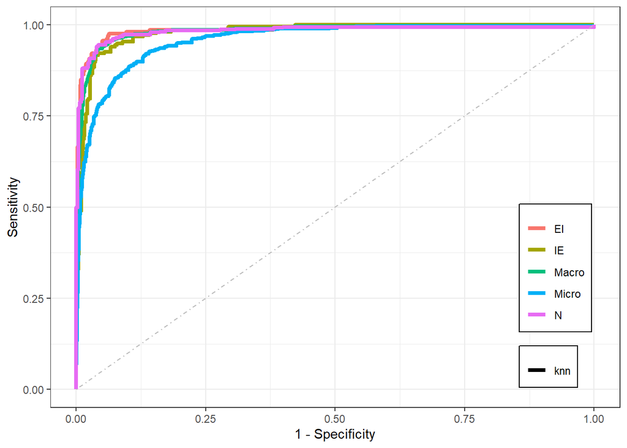

```r
# ROC plot

pred_knn <- predict(knn, x_dummy_test, type='prob')
pred_knn <- data.frame(pred_knn)
colnames(pred_knn) <- paste(colnames(pred_knn), "_pred_knn")

# Merge true labels and predicted values
true_label <- dummies::dummy(y_test, sep = ".")
true_label <- data.frame(true_label)
colnames(true_label) <- gsub(".*?\\.", "", colnames(true_label))
colnames(true_label) <- paste(colnames(true_label), "_true")

final_df <- cbind(true_label, pred_knn)


# multiROC

require(multiROC)
roc_res <- multi_roc(final_df, force_diag=T)

# Plot
plot_roc_df <- plot_roc_data(roc_res)

require(ggplot2)
ggplot(plot_roc_df, aes(x = 1-Specificity, y=Sensitivity)) +
  geom_path(aes(color = Group, linetype=Method), size=1.5) +
  geom_segment(aes(x = 0, y = 0, xend = 1, yend = 1),
                        colour='grey', linetype = 'dotdash') +
  theme_bw() +
  theme(plot.title = element_text(hjust = 0.5),
                 legend.justification=c(1, 0), legend.position=c(.95, .05),
                 legend.title=element_blank(),
                 legend.background = element_rect(fill=NULL, size=0.5,
                                                           linetype="solid", colour ="black"))
```

```r
# AUC

prob <- predict(knn, x_dummy_test, type='prob')
auc_knn <- multiclass.roc(y_test,prob)

#AUC score
auc_knn
```

```
##
## Call:
## multiclass.roc.default(response = y_test, predictor = prob)
##
## Data: multivariate predictor prob with 3 levels of y_test: EI, IE, N.
## Multi-class area under the curve: 0.9854
```

```r
#confusion matrix
cm <- table(y_test, pred_class_knn )
cm
```

```
##       pred_class_knn
## y_test  EI  IE   N
##     EI 203   3   1
##     IE   8 209   1
##     N   70  64 398
```

```r
#Specificity

Specificty_class_EI <- (cm[2, 2] + cm[3, 3])/(cm[2, 1] + cm[3, 1] + cm[2, 2] + cm[3, 3])

Specificty_class_IE <- (cm[1, 1] + cm[3, 3])/(cm[1, 2] + cm[3, 2] + cm[1, 1] + cm[3, 3])

Specificty_class_N <- (cm[2, 2] + cm[1, 1])/(cm[1, 3] + cm[2, 3] + cm[2, 2] + cm[1, 1])

spec_knn <- matrix(c(Specificty_class_EI,Specificty_class_IE,Specificty_class_N),nrow=1,dimnames=list("",c("EI","IE","N")))
spec_knn
```

```
##         EI        IE         N
##  0.8861314 0.8997006 0.9951691
```

```r
#Precision
prec_knn <- (diag(cm) / colSums(cm))
prec_knn
```

```
##        EI        IE         N
## 0.7224199 0.7572464 0.9950000
```

```r
#Recall(sensitivity) for each class
recall_knn <- (diag(cm) / rowSums(cm))
recall_knn
```

```
##        EI        IE         N
## 0.9806763 0.9587156 0.7481203
```

```r
# Variance Estimation

# Get indices for 90% of the total number of samples
varEst_tridx=sample(1:nrow(train), 0.9*nrow(train), replace=F)

 # Define training data for variance estimation

varEst_trdf=train[varEst_tridx,]

# Define variance estimation partition
varEst_tstdf=train[-varEst_tridx,]

varEst=function(trdf,tstdf,percent,type){
  target_idx=which(names(trdf)=="Class")

  # Initialize a variable to store the ac curacies computed in the loop
  acc_varEstp=c();
  for(i in 1:100){

    # Take samples, percent% of the data
    varEstp_tridx=sample(1:nrow(trdf), percent/100*nrow(trdf), replace=F)
  varEstp_trdf=trdf[varEstp_tridx,]
  if(type=="multinom"){
    mn_model_varEstp=nnet::multinom(Class~attribute_30 +attribute_29+attribute_31+attribute_32+ attribute_35+attribute_33 + attribute_28 + attribute_34+ attribute_36 + attribute_23 +attribute_25+attribute_20+attribute_22 + attribute_26 + attribute_21 + attribute_24 + attribute_17 + attribute_16, varEstp_trdf, maxit=1000, trace=F)

    #Train a multinomial model

    pred_varEstp=predict(mn_model_varEstp, tstdf[,-target_idx], type="class")

# Predict with variance estimation partition

  }
  else if(type=="svm"){
    varEstp_trdf$Class=as.factor(varEstp_trdf$Class)
    svm_model_varEstp=svm(Class~attribute_30 +attribute_29+attribute_31+attribute_32+ attribute_35+attribute_33 + attribute_28 + attribute_34+ attribute_36 + attribute_23 +attribute_25+attribute_20+attribute_22 + attribute_26 + attribute_21 + attribute_24 + attribute_17 + attribute_16,data=varEstp_trdf)

    # Train a svm model

    pred_varEstp=predict(svm_model_varEstp, tstdf[,-target_idx], type="class")

# Predict with variance estimation partition
  }
  else if(type=="tree"){
    tree_model_varEstp=rpart(Class~attribute_30 +attribute_29+attribute_31+attribute_32+ attribute_35+attribute_33 + attribute_28 + attribute_34+ attribute_36 + attribute_23 +attribute_25+attribute_20+attribute_22 + attribute_26 + attribute_21 + attribute_24 + attribute_17 + attribute_16,data=varEstp_trdf)

    # Train a svm model
    pred_varEstp=predict(tree_model_varEstp, tstdf[,-target_idx], type="class")

# Predict with variance estimation partition
  }
  else if(type=="knn"){

    #preparing data

    x_train <- varEstp_trdf[,c('attribute_30', 'attribute_29', 'attribute_31', 'attribute_32', 'attribute_35', 'attribute_33', 'attribute_28', 'attribute_34', 'attribute_36', 'attribute_23', 'attribute_25', 'attribute_20', 'attribute_22', 'attribute_26', 'attribute_21', 'attribute_24', 'attribute_17', 'attribute_16')]
    trclass <- varEstp_trdf$Class

    x_test <- tstdf[,c('attribute_30', 'attribute_29', 'attribute_31', 'attribute_32', 'attribute_35', 'attribute_33', 'attribute_28', 'attribute_34', 'attribute_36', 'attribute_23', 'attribute_25', 'attribute_20', 'attribute_22', 'attribute_26', 'attribute_21', 'attribute_24', 'attribute_17', 'attribute_16')]
    tstclass <- tstdf$Class


    # Create dummy variable since KNN only handles numerical variables

    varEstp_trdf <- dummy_cols(x_train, select_columns = colnames(x_train), remove_selected_columns = T)
    tstdf1 <- dummy_cols(x_test, select_columns = colnames(x_test), remove_selected_columns = T)

    pred_varEstp=knn(varEstp_trdf[,-target_idx], tstdf1[,-target_idx], trclass,k = 15, prob=TRUE)
  }
  else{
    print("type should be 'multinom' 'svm' 'tree' or 'knn'")
 return()
  }

  # Avoids issues when number of classes are not equal
  u_varEstp=union(pred_varEstp, tstdf[,target_idx])
  t_varEstp=table(factor(pred_varEstp, u_varEstp), factor(tstdf[,target_idx], u_varEstp))

   # Confusion Matrix
  mn_cfm_varEstp=confusionMatrix(t_varEstp)

     # Accuracy of predictions

  mn_acc_varEstp=mn_cfm_varEstp$overall[['Accuracy']]

  acc_varEstp=c(acc_varEstp,mn_acc_varEstp)

  # Store
  }

  mean_varEstp=signif(mean(acc_varEstp),4)
  var_varEstp=signif(var(acc_varEstp),4)
  varEstp=data.frame(mean_varEstp,var_varEstp)
  names(varEstp)=c("Mean of Accuracies","Variance of Accuracies")
  return(t(varEstp))
}
```

```r
#for Logistic

# Variance estimation using 30% of the data
mn_varEst30=varEst(varEst_trdf, varEst_tstdf, 30, type="multinom")

# Variance estimation using 60% of the data
mn_varEst60=varEst(varEst_trdf, varEst_tstdf, 60, type="multinom")

# Variance estimation using 100% of the data
mn_varEst100=varEst(varEst_trdf, varEst_tstdf, 100, type="multinom")

print("Logistic-Regression Variance Estimation using 30% of data:")
```

```
## [1] "Logistic-Regression Variance Estimation using 30% of data:"
```

```r
mn_varEst30
```

```
##                             [,1]
## Mean of Accuracies     0.9070000
## Variance of Accuracies 0.0004349
```

```r
print("Logistic-Regression Variance Estimation using 60% of data:")
```

```
## [1] "Logistic-Regression Variance Estimation using 60% of data:"
```